# Selection in de novo mutations - DDD

Federico Abascal

04/10/2019

### Introduction

This exercise shows how to run **dndscv** with *de novo* mutations. These are mutations that happen in the germline (or during early embryogenesis) and hence are not present in the parents. The mutation data comes from the *Deciphering Developmental Disorders* Project (DDD), published in *Nature* 542.7642 (2017): 433.

These data is very valuable to understand if mutation is responsible for DDs and, if so, which genes are involved.

#### Data analysis

As in the other exercises:

```r
library("dndscv")
```

For this study we need the file: **ddd.tsv**. Save the file in a folder of your computer and set the working directory accordingly

```r
working_directory = "/Users/fa8/Documents/Presentaciones/Romania/tutorial_and_mutation_datasets"
setwd(working_directory)
```

Load variants:

```r
mutations = read.table("ddd.tsv",sep="\t",stringsAsFactors=F,header=T)
```

It’s always good to have a look at the data before doing any analysis. Number of mutations and samples

```r
nrow(mutations)
```

```
## [1] 7801
```

```r
length(unique(mutations$sampleID))
```

```
## [1] 3586
```

Histogram of number of mutations per sample

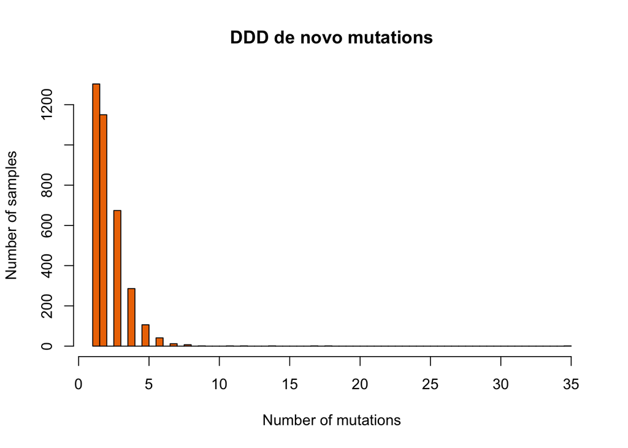

```r
hist(table(mutations$sampleID),main="DDD de novo mutations",xlab="Number of mutations",ylab="Number of samples",breaks=50,col="darkorange2")
```

The histogram shows there are few *de novo* mutations per sample. This is expected.

#### Selection analysis:

Run dndscv:

```r
dnds_ddd = dndscv(mutations)
```

Let’s look at the global dN/dS:

```r
print(dnds_ddd$globaldnds,digits=3)
```

```
##      name  mle cilow cihigh
## wmis wmis 1.24  1.17   1.32
## wnon wnon 2.09  1.85   2.35
## wspl wspl 1.86  1.58   2.19
## wtru wtru 2.01  1.82   2.22
## wall wall 1.30  1.23   1.38
```

**What does it mean dN/dS > 1?**

These individuals show more non-synonymous mutations than expected by chance, implying that those mutations might be responsible for the developmental disorder phenotype.

About 20% of the missense mutations and 52% of the nonsense mutations are predicted to be positively selected.

```r
table(dnds_ddd$annotmuts$impact)
```

```
##
## Essential_Splice         Missense           no-SNV         Nonsense
##              203             4714              821              397
##        Stop_loss       Synonymous
##                5             1661
```

**Which genes show evidence of positive selection?**

Let’s print only some columns for the easier

```r
print(dnds_ddd$sel_cv[which(dnds_ddd$sel_cv$qglobal_cv<0.05),c("gene_name", "n_syn", "n_mis", "n_non", "n_spl", "n_ind", "qglobal_cv")],digits=3)
```

```
##         gene_name n_syn n_mis n_non n_spl n_ind qglobal_cv
## 4888        DDX3X     0    12     5     4     6   0.00e+00
## 10286       MECP2     1     7     6     0     1   0.00e+00
## 19076       WDR45     0     3     2     5     0   0.00e+00
## 9204        KMT2A     0     4     9     3    15   0.00e+00
## 1466       ARID1B     0     2    10     3    17   0.00e+00
## 5429       DYRK1A     0     4     5     2     7   0.00e+00
## 649          ADNP     0     2     8     0    10   0.00e+00
## 4539       CTNNB1     0     0     7     0     4   8.36e-13
## 15592       SETD5     0     2     5     2     7   8.48e-12
## 684   AF196779.12     0     2     2     4     0   8.48e-12
## 17293        TCF4     0     4     3     2     3   1.54e-10
## 7753        HDAC8     0     6     2     1     0   1.54e-10
## 13491     PPP2R5D     0    12     0     0     0   6.35e-10
## 15302       SATB2     0     5     2     1     6   9.75e-10
```

[output cut: 61 more lines]

There are 75 genes with evidence of positive selection! Including: DDX3X, MECP2, WDR45, KMT2A, ARID1B, … Some involved in chromatin organization, others in synapses, etc